# Annual Review of Child Welfare Indicators

## (Page 1 Copy)

## In Memoriam Representative Roger Freeman (1965 - 2014)

The 1st Annual Review of Child Welfare Indicators for Washington is dedicated to the memory of State Representative Roger Freeman (D-30 Federal Way) - the sponsor of the legislative initiative which created the review.

Representative Freeman was a passionate and tireless advocate for social justice and equal opportunities for the children and families of Washington State.

This review has been humbly written in his honor.

## (Page 2 Copy)

### Goal

The goal of the annual review is to provide the public with information concerning the safety, permanency, and well-being of the children and families served by the child welfare system. The information in this review is designed to provide a detailed understanding of the system’s performance in these domains and to help the state government in determining priorities for the investment of public dollars or other legislative activities to facilitate improvement in these domains.

### What is the Annual Review?

The annual review is the result of a legislative initiative started in 2013 to help Washington better understand how children served by the state child welfare system were faring in the domains of safety, permanency, and well-being. The annual review does not replace requirements by the state to submit to other reporting requirements required by state or federal law. The annual review is, however, an attempt for Washington child welfare stakeholders to identify key metrics that will help the public understand how the child welfare system is performing and to monitor those metrics over time. The metrics identified here represent the best thinking, to-date, concerning child welfare system performance in the areas of safety, permanency, and well-being. While some of these metrics may remain a part of the annual review indefinitely, some of the measurement definitions may change or even be eliminated as new data or better measurement techniques become available.

### Background of the Annual Review (AR)

In 2013, the Washington State Legislature passed two pieces of legislation: Engrossed Substitute House Bill 1774 (ESHB 1774) and Second Substitute House Bill 1566 (SSHB 1566). The first bill was a broad mandate for a university-based research center to engage in the collaborative development of metrics concerning the safety, permanency, and well-being of children served by the child welfare system in Washington. The second bill is more specifically focused on the educational outcomes of foster children. In support of the goal of unified measurement for the child welfare system (i.e. a single set of measurements as opposed to disparate measurements resulting from different initiatives), the legislature mandated through SSHB 1566 that the research center include, as a part of the reports under ESHB 1774, several specific measurements concerning the educational progress of foster children in Washington.

Partners for Our Children (POC), at the University of Washington (UW) School of Social Work, was chosen as the research center to perform the annual review required by the legislation mentioned above. POC was specifically chosen due to the growing analytic capacity of POC resulting from private philanthropic investments in projects such as the Washington State Child Well-being Data Portal (hereafter, the Data Portal). Such efforts allow POC to perform the activities required under this legislation within its existing resources and without the expenditure of new state dollars. POC’s association with the UW also provides for collaboration with relevant subject-matter experts and institutions located at the UW. For example, the measures identified under SSHB 1566 make use of data obtained at the UW under previously existing data sharing agreements between the UW’s Center for Educational Data Research (CEDR) and the state’s educational data centers - the Office of the Superintendent of Public Instruction (OSPI) and the Educational Research and Data Center (ERDC). Thus, by relying on POC to fulfill the reporting requirements of the annual review, the state was able to meet the requirements of this legislation with no additional expenditures from the state general fund.

## (Page 3 Copy)

### The Annual Review Process - Implementing a Philosophy of Continuous Quality Improvement

Following guidance from the federal government and long-standing advice from national child welfare organizations, CA has implemented a robust Quality Assurance and Continuous Quality Improvement system within the organization since the 1990s.

[figure not shown]

The annual review fits into the “study” component of the CQI process as shown in the graphic below. Starting this year, when the annual review process reveals a trend or metric that is of potential interest to stakeholders, a plan will be developed to conduct a formal analysis of the metric during the subsequent annual review period. The results of the analysis are then reported back to the legislature on or before the next annual review date and can be used to begin the “planning” portion of the CQI process. In this way, the annual review should not be thought of as a performance evaluation or report card. Rather, the annual review should be conceptualized as a quality improvement tool for the state child welfare system.

[figure not shown]

## (Page 4 Copy)

### How were the annual review measured developed?

The measures that were chosen for the first annual review were developed based on feedback from child welfare stakeholders throughout Washington and through a close working relationship between the staff of CA, the Research and Data Analysis (RDA) unit of DSHS, POC, CEDR, OSPI, and ERDC. Measurements utilized for the first annual review represent those measures which can be calculated with relative ease within the confines of existing state resources and data sets. Future annual reviews will seek to further refine and expand these measurements - particularly within the domain of child well-being.

### Our Approach to Measurement

The graphic below outlines the way children and families move from one part of the child welfare system to another. While we don’t measure all parts of the system specifically, we do take all parts of the system into account in the definition of our measures.

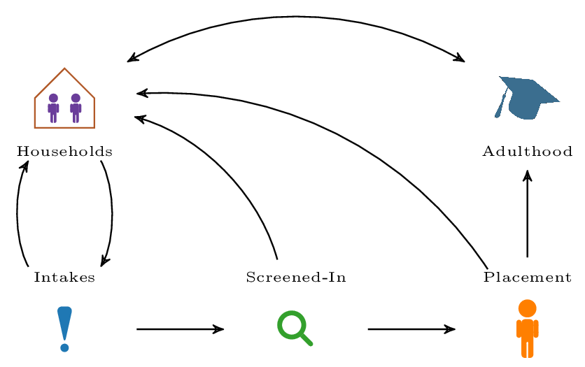

Many of the measures that we deal with are child-specific measures. For these measures, we tend to look at cohorts of children (i.e. children entering the system at a particular point in time) or the number of days that kids stay in the system (i.e. care days). These measures focus on the transition between placement and household on the graphic above or the experience of a child within a particular placement. Other measures are household level measures. These measures focus more broadly on transitions between the different points in the graphic.

### Our Approach to Monitoring Change

In order to assess whether or not a particular measure is undergoing any change, the use of statistical process control techniques is proposed. A common tool in statistical process control, is referred to as an “attribute control chart” or just “control chart”.

The goal of a control chart is to measure a particular attribute across a number of different cases. All of the measurements in this document can be reduced to this definition. A standard control chart is a two-dimensional graph with the x-axis representing time and the y-axis representing the outcome of whatever process we want to keep in control. Three lines are plotted on the chart: 1) a top line which identifies the upper limit of “acceptable” values, 2) a center line which identifies the value we would expect to see (perhaps based on previous years’ performance), and 3) a bottom line which identifies the lower limit of “acceptable” values.

Within Expectations - Within our upper and lower control limits. Below Expectations - Below our lower control limit for a given measure. Above Expectations - Above our upper control limit for a given measure. Monitoring Period - Below 10 years of data - continuing to monitor and study trend.

Trending Up - Based on our available data, apparently trending up. Trending Down - Baed on our available data, apparently trending down. Stable - Based on our available data, not moving up or down.

Trend is within expected variation based on historical trends and is consistent with our understanding of system dynamics and the risk profile of the children and families served by the child welfare system OR the trend is outside of the expected variation but in a direction that is consistent with our expectations of a well-functioning child welfare system.